# Starbucks Capstone Challenge

### Introduction

This data set contains simulated data that mimics customer behavior on the Starbucks rewards mobile app. Once every few days, Starbucks sends out an offer to users of the mobile app. An offer can be merely an advertisement for a drink or an actual offer such as a discount or BOGO (buy one get one free). Some users might not receive any offer during certain weeks.

Not all users receive the same offer, and that is the challenge to solve with this data set.

Your task is to combine transaction, demographic and offer data to determine which demographic groups respond best to which offer type. This data set is a simplified version of the real Starbucks app because the underlying simulator only has one product whereas Starbucks actually sells dozens of products.

Every offer has a validity period before the offer expires. As an example, a BOGO offer might be valid for only 5 days. You'll see in the data set that informational offers have a validity period even though these ads are merely providing information about a product; for example, if an informational offer has 7 days of validity, you can assume the customer is feeling the influence of the offer for 7 days after receiving the advertisement.

You'll be given transactional data showing user purchases made on the app including the timestamp of purchase and the amount of money spent on a purchase. This transactional data also has a record for each offer that a user receives as well as a record for when a user actually views the offer. There are also records for when a user completes an offer.

Keep in mind as well that someone using the app might make a purchase through the app without having received an offer or seen an offer.

### Example

To give an example, a user could receive a discount offer buy 10 dollars get 2 off on Monday. The offer is valid for 10 days from receipt. If the customer accumulates at least 10 dollars in purchases during the validity period, the customer completes the offer.

However, there are a few things to watch out for in this data set. Customers do not opt into the offers that they receive; in other words, a user can receive an offer, never actually view the offer, and still complete the offer. For example, a user might receive the "buy 10 dollars get 2 dollars off offer", but the user never opens the offer during the 10 day validity period. The customer spends 15 dollars during those ten days. There will be an offer completion record in the data set; however, the customer was not influenced by the offer because the customer never viewed the offer.

### Cleaning

This makes data cleaning especially important and tricky.

You'll also want to take into account that some demographic groups will make purchases even if they don't receive an offer. From a business perspective, if a customer is going to make a 10 dollar purchase without an offer anyway, you wouldn't want to send a buy 10 dollars get 2 dollars off offer. You'll want to try to assess what a certain demographic group will buy when not receiving any offers.

### Final Advice

Because this is a capstone project, you are free to analyze the data any way you see fit. For example, you could build a machine learning model that predicts how much someone will spend based on demographics and offer type. Or you could build a model that predicts whether or not someone will respond to an offer. Or, you don't need to build a machine learning model at all. You could develop a set of heuristics that determine what offer you should send to each customer (i.e., 75 percent of women customers who were 35 years old responded to offer A vs 40 percent from the same demographic to offer B, so send offer A).

# Data Sets

The data is contained in three files:

- portfolio.json - containing offer ids and meta data about each offer (duration, type, etc.)
- profile.json - demographic data for each customer
- transcript.json - records for transactions, offers received, offers viewed, and offers completed

Here is the schema and explanation of each variable in the files:

**portfolio.json**

- id (string) - offer id
- offer_type (string) - type of offer ie BOGO, discount, informational
- difficulty (int) - minimum required spend to complete an offer
- reward (int) - reward given for completing an offer
- duration (int) - time for offer to be open, in days
- channels (list of strings)

**profile.json**

- age (int) - age of the customer
- became_member_on (int) - date when customer created an app account
- gender (str) - gender of the customer (note some entries contain 'O' for other rather than M or F)
- id (str) - customer id
- income (float) - customer's income

**transcript.json**

- event (str) - record description (ie transaction, offer received, offer viewed, etc.)
- person (str) - customer id
- time (int) - time in hours since start of test. The data begins at time t=0
- value - (dict of strings) - either an offer id or transaction amount depending on the record

**Note:** If you are using the workspace, you will need to go to the terminal and run the command `conda update pandas` before reading in the files. This is because the version of pandas in the workspace cannot read in the transcript.json file correctly, but the newest version of pandas can. You can access the termnal from the orange icon in the top left of this notebook.

You can see how to access the terminal and how the install works using the two images below. First you need to access the terminal:

[figure not shown]

Then you will want to run the above command:

[figure not shown]

Finally, when you enter back into the notebook (use the jupyter icon again), you should be able to run the below cell without any errors.

```python
#Import libraries
import pandas as pd
import numpy as np
import math
import json
import re
import seaborn as sb
import time
import progressbar
import matplotlib.pyplot as plt

# read in the json files
portfolio = pd.read_json('data/portfolio.json',
                        orient='records', lines=True)
profile = pd.read_json('data/profile.json',
                       orient='records', lines=True)
transcript = pd.read_json('data/transcript.json',
                          orient='records', lines=True)
```

```python
transcript.head()
```

|  | person | event | value | time |
| --- | --- | --- | --- | --- |
| 0 | 78afa995795e4d85b5d9ceeca43f5fef | offer received | {'offer id': '9b98b8c7a33c4b65b9aebfe6a799e6d9'} | 0 |
| 1 | a03223e636434f42ac4c3df47e8bac43 | offer received | {'offer id': '0b1e1539f2cc45b7b9fa7c272da2e1d7'} | 0 |
| 2 | e2127556f4f64592b11af22de27a7932 | offer received | {'offer id': '2906b810c7d4411798c6938adc9daaa5'} | 0 |
| 3 | 8ec6ce2a7e7949b1bf142def7d0e0586 | offer received | {'offer id': 'fafdcd668e3743c1bb461111dcafc2a4'} | 0 |
| 4 | 68617ca6246f4fbc85e91a2a49552598 | offer received | {'offer id': '4d5c57ea9a6940dd891ad53e9dbe8da0'} | 0 |

```python
#Declare regex
regex = re.compile('[^a-zA-Z]')

#Create function for new columns
create_data_offer = lambda x: list(x.items())[0][1] if regex.sub('', str(x).split(':')[0]) == 'offerid' else np.nan
create_data_amount = lambda x: list(x.items())[0][1] if regex.sub('', str(x).split(':')[0]) != 'offerid' else np.nan

#Apply previous function to create new columns
transcript['offer_id'] = transcript['value'].apply(create_data_offer)
transcript['amount'] = transcript['value'].apply(create_data_amount)

#Drop used column
transcript.drop(columns=['value'], inplace=True)
```

```python
#Rename columns accordingly
transcript = transcript.rename(columns={"person": "customer_id"})
profile = profile.rename(columns={"id": "customer_id"})
```

```python
#Merge the three datasets into one final dataset
temp1 = pd.merge(transcript, profile,
                 how='left', on=['customer_id'])
portfolio = portfolio.rename(
    columns={"id": "offer_id"})
df = pd.merge(temp1, portfolio,
              how='left', on=['offer_id'])

#Show final dataset
df.head()
```

|  | event | customer_id | time | offer_id | amount | age | became_member_on | gender | income | channels | difficulty | duration | offer_type | reward |
| --- | --- | --- | --- | --- | --- | --- | --- | --- | --- | --- | --- | --- | --- | --- |
| 0 | offer received | 78afa995795e4d85b5d9ceeca43f5fef | 0 | 9b98b8c7a33c4b65b9aebfe6a799e6d9 | NaN | 75 | 20170509 | F | 100000.0 | [web, email, mobile] | 5.0 | 7.0 | bogo | 5.0 |
| 1 | offer received | a03223e636434f42ac4c3df47e8bac43 | 0 | 0b1e1539f2cc45b7b9fa7c272da2e1d7 | NaN | 118 | 20170804 | None | NaN | [web, email] | 20.0 | 10.0 | discount | 5.0 |
| 2 | offer received | e2127556f4f64592b11af22de27a7932 | 0 | 2906b810c7d4411798c6938adc9daaa5 | NaN | 68 | 20180426 | M | 70000.0 | [web, email, mobile] | 10.0 | 7.0 | discount | 2.0 |
| 3 | offer received | 8ec6ce2a7e7949b1bf142def7d0e0586 | 0 | fafdcd668e3743c1bb461111dcafc2a4 | NaN | 118 | 20170925 | None | NaN | [web, email, mobile, social] | 10.0 | 10.0 | discount | 2.0 |
| 4 | offer received | 68617ca6246f4fbc85e91a2a49552598 | 0 | 4d5c57ea9a6940dd891ad53e9dbe8da0 | NaN | 118 | 20171002 | None | NaN | [web, email, mobile, social] | 10.0 | 5.0 | bogo | 10.0 |

```python
#Create dummy variables
dummy_variables = pd.get_dummies(df.channels.apply(pd.Series).stack()).sum(level=0)
df = pd.concat([df, dummy_variables],
               axis=1)

#Drop used column
df.drop(columns=['channels'], inplace=True)

#Show data
df.head()
```

|  | event | customer_id | time | offer_id | amount | age | became_member_on | gender | income | difficulty | duration | offer_type | reward | email | mobile | social | web |
| --- | --- | --- | --- | --- | --- | --- | --- | --- | --- | --- | --- | --- | --- | --- | --- | --- | --- |
| 0 | offer received | 78afa995795e4d85b5d9ceeca43f5fef | 0 | 9b98b8c7a33c4b65b9aebfe6a799e6d9 | NaN | 75 | 20170509 | F | 100000.0 | 5.0 | 7.0 | bogo | 5.0 | 1.0 | 1.0 | 0.0 | 1.0 |
| 1 | offer received | a03223e636434f42ac4c3df47e8bac43 | 0 | 0b1e1539f2cc45b7b9fa7c272da2e1d7 | NaN | 118 | 20170804 | None | NaN | 20.0 | 10.0 | discount | 5.0 | 1.0 | 0.0 | 0.0 | 1.0 |
| 2 | offer received | e2127556f4f64592b11af22de27a7932 | 0 | 2906b810c7d4411798c6938adc9daaa5 | NaN | 68 | 20180426 | M | 70000.0 | 10.0 | 7.0 | discount | 2.0 | 1.0 | 1.0 | 0.0 | 1.0 |
| 3 | offer received | 8ec6ce2a7e7949b1bf142def7d0e0586 | 0 | fafdcd668e3743c1bb461111dcafc2a4 | NaN | 118 | 20170925 | None | NaN | 10.0 | 10.0 | discount | 2.0 | 1.0 | 1.0 | 1.0 | 1.0 |
| 4 | offer received | 68617ca6246f4fbc85e91a2a49552598 | 0 | 4d5c57ea9a6940dd891ad53e9dbe8da0 | NaN | 118 | 20171002 | None | NaN | 10.0 | 5.0 | bogo | 10.0 | 1.0 | 1.0 | 1.0 | 1.0 |

```python
#Create copy for further wrangling
df_final = df.copy()

#Create dummy variables for categorical data
dummy_variables = pd.get_dummies(df_final.offer_type)
df_final = pd.concat([df_final, dummy_variables],
                     axis=1)

#Drop used column
df_final.drop(columns=['offer_type'], inplace=True)

#Show dataset
df_final.head()
```

|  | event | customer_id | time | offer_id | amount | age | became_member_on | gender | income | difficulty | duration | reward | email | mobile | social | web | bogo | discount | informational |
| --- | --- | --- | --- | --- | --- | --- | --- | --- | --- | --- | --- | --- | --- | --- | --- | --- | --- | --- | --- |
| 0 | offer received | 78afa995795e4d85b5d9ceeca43f5fef | 0 | 9b98b8c7a33c4b65b9aebfe6a799e6d9 | NaN | 75 | 20170509 | F | 100000.0 | 5.0 | 7.0 | 5.0 | 1.0 | 1.0 | 0.0 | 1.0 | 1 | 0 | 0 |
| 1 | offer received | a03223e636434f42ac4c3df47e8bac43 | 0 | 0b1e1539f2cc45b7b9fa7c272da2e1d7 | NaN | 118 | 20170804 | None | NaN | 20.0 | 10.0 | 5.0 | 1.0 | 0.0 | 0.0 | 1.0 | 0 | 1 | 0 |
| 2 | offer received | e2127556f4f64592b11af22de27a7932 | 0 | 2906b810c7d4411798c6938adc9daaa5 | NaN | 68 | 20180426 | M | 70000.0 | 10.0 | 7.0 | 2.0 | 1.0 | 1.0 | 0.0 | 1.0 | 0 | 1 | 0 |
| 3 | offer received | 8ec6ce2a7e7949b1bf142def7d0e0586 | 0 | fafdcd668e3743c1bb461111dcafc2a4 | NaN | 118 | 20170925 | None | NaN | 10.0 | 10.0 | 2.0 | 1.0 | 1.0 | 1.0 | 1.0 | 0 | 1 | 0 |
| 4 | offer received | 68617ca6246f4fbc85e91a2a49552598 | 0 | 4d5c57ea9a6940dd891ad53e9dbe8da0 | NaN | 118 | 20171002 | None | NaN | 10.0 | 5.0 | 10.0 | 1.0 | 1.0 | 1.0 | 1.0 | 1 | 0 | 0 |

```python
#Drop rows that have NaN value on gender
df_final.dropna(subset=['gender'], inplace=True)

#Create dummy variables for gender
dummy_variables = pd.get_dummies(df_final.gender)
df_final = pd.concat([df_final, dummy_variables],
                     axis=1)

#Drop used column
df_final.drop(columns=['gender'], inplace=True)

#Show dataset
df_final.head()
```

|  | event | customer_id | time | offer_id | amount | age | became_member_on | income | difficulty | duration | ... | email | mobile | social | web | bogo | discount | informational | F | M | O |
| --- | --- | --- | --- | --- | --- | --- | --- | --- | --- | --- | --- | --- | --- | --- | --- | --- | --- | --- | --- | --- | --- |
| 0 | offer received | 78afa995795e4d85b5d9ceeca43f5fef | 0 | 9b98b8c7a33c4b65b9aebfe6a799e6d9 | NaN | 75 | 20170509 | 100000.0 | 5.0 | 7.0 | ... | 1.0 | 1.0 | 0.0 | 1.0 | 1 | 0 | 0 | 1 | 0 | 0 |
| 2 | offer received | e2127556f4f64592b11af22de27a7932 | 0 | 2906b810c7d4411798c6938adc9daaa5 | NaN | 68 | 20180426 | 70000.0 | 10.0 | 7.0 | ... | 1.0 | 1.0 | 0.0 | 1.0 | 0 | 1 | 0 | 0 | 1 | 0 |
| 5 | offer received | 389bc3fa690240e798340f5a15918d5c | 0 | f19421c1d4aa40978ebb69ca19b0e20d | NaN | 65 | 20180209 | 53000.0 | 5.0 | 5.0 | ... | 1.0 | 1.0 | 1.0 | 1.0 | 1 | 0 | 0 | 0 | 1 | 0 |
| 7 | offer received | 2eeac8d8feae4a8cad5a6af0499a211d | 0 | 3f207df678b143eea3cee63160fa8bed | NaN | 58 | 20171111 | 51000.0 | 0.0 | 4.0 | ... | 1.0 | 1.0 | 0.0 | 1.0 | 0 | 0 | 1 | 0 | 1 | 0 |
| 8 | offer received | aa4862eba776480b8bb9c68455b8c2e1 | 0 | 0b1e1539f2cc45b7b9fa7c272da2e1d7 | NaN | 61 | 20170911 | 57000.0 | 20.0 | 10.0 | ... | 1.0 | 0.0 | 0.0 | 1.0 | 0 | 1 | 0 | 1 | 0 | 0 |

5 rows × 21 columns

```python
#Change datatype to datetime
df_final['became_member_on'] = pd.to_datetime(df_final['became_member_on'] ,
                                              format='%Y%m%d', errors='ignore')

#Create new column of year and month
df_final['member_year'] = df_final.became_member_on.dt.year
df_final['member_month'] = df_final.became_member_on.dt.month

#Show datatype and dataset
print(df_final.dtypes)
df_final.head()
```

```
event                       object
customer_id                 object
time                         int64
offer_id                    object
amount                     float64
age                          int64
became_member_on    datetime64[ns]
income                     float64
difficulty                 float64
duration                   float64
reward                     float64
email                      float64
mobile                     float64
social                     float64
web                        float64
bogo                         uint8
discount                     uint8
informational                uint8
F                            uint8
M                            uint8
O                            uint8
member_year                  int64
member_month                 int64
dtype: object
```

|  | event | customer_id | time | offer_id | amount | age | became_member_on | income | difficulty | duration | ... | social | web | bogo | discount | informational | F | M | O | member_year | member_month |
| --- | --- | --- | --- | --- | --- | --- | --- | --- | --- | --- | --- | --- | --- | --- | --- | --- | --- | --- | --- | --- | --- |
| 0 | offer received | 78afa995795e4d85b5d9ceeca43f5fef | 0 | 9b98b8c7a33c4b65b9aebfe6a799e6d9 | NaN | 75 | 2017-05-09 | 100000.0 | 5.0 | 7.0 | ... | 0.0 | 1.0 | 1 | 0 | 0 | 1 | 0 | 0 | 2017 | 5 |
| 2 | offer received | e2127556f4f64592b11af22de27a7932 | 0 | 2906b810c7d4411798c6938adc9daaa5 | NaN | 68 | 2018-04-26 | 70000.0 | 10.0 | 7.0 | ... | 0.0 | 1.0 | 0 | 1 | 0 | 0 | 1 | 0 | 2018 | 4 |
| 5 | offer received | 389bc3fa690240e798340f5a15918d5c | 0 | f19421c1d4aa40978ebb69ca19b0e20d | NaN | 65 | 2018-02-09 | 53000.0 | 5.0 | 5.0 | ... | 1.0 | 1.0 | 1 | 0 | 0 | 0 | 1 | 0 | 2018 | 2 |
| 7 | offer received | 2eeac8d8feae4a8cad5a6af0499a211d | 0 | 3f207df678b143eea3cee63160fa8bed | NaN | 58 | 2017-11-11 | 51000.0 | 0.0 | 4.0 | ... | 0.0 | 1.0 | 0 | 0 | 1 | 0 | 1 | 0 | 2017 | 11 |
| 8 | offer received | aa4862eba776480b8bb9c68455b8c2e1 | 0 | 0b1e1539f2cc45b7b9fa7c272da2e1d7 | NaN | 61 | 2017-09-11 | 57000.0 | 20.0 | 10.0 | ... | 0.0 | 1.0 | 0 | 1 | 0 | 1 | 0 | 0 | 2017 | 9 |

5 rows × 23 columns

```python
#Separate data which the offer is completed
df_complete = df_final.query('event == "offer completed"')
duration = []
# df_complete_receive = pd.DataFrame(columns=df_final.columns)
df_complete_receive = []

#Separate data where received offer is not completed
df_receive = df_final.query('event == "offer received"')
df_incomplete = []

#Iterate over dataset
if len(df_complete) > len(df_receive):
    loop_length = len(df_complete)
else:
    loop_length = len(df_receive)

#Add progress bar
bar = progressbar.ProgressBar(max_value=loop_length)

for i in range(loop_length):
    if i < len(df_complete):
        c_customer_id = df_complete.iloc[i].customer_id
        c_complete_time = df_complete.iloc[i].time
        c_offer_id = df_complete.iloc[i].offer_id

        receive_offer = df_final.query('event == "offer received" and time <= @c_complete_time and offer_id == @c_offer_id and customer_id == @c_customer_id')
        duration.append(c_complete_time - (receive_offer['time'].values)[0])
        df_complete_receive.append(receive_offer.iloc[0,:].values)

    if i < len(df_receive):
        i_customer_id = df_receive.iloc[i].customer_id
        i_receive_time = df_receive.iloc[i].time
        i_offer_id = df_receive.iloc[i].offer_id

        if len(df_final.query('event == "offer completed" and time >= @i_receive_time and offer_id == @i_offer_id and customer_id == @i_customer_id')) == 0:
            df_incomplete.append(df_receive.iloc[i].values) #no completed offer found
        else:
            pass
    bar.update(i)

bar.finish()
```

```
100% (66501 of 66501) |##################| Elapsed Time: 1:04:26 Time:  1:04:26
```

```python
#Add new column for the duration from receiving offer to compeleting it
df_complete['time_before_complete'] = duration
```

```
Text(0.5,1,'Histogram of Transactions by Hours')
```

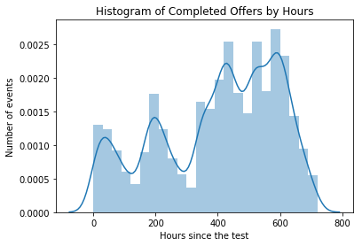

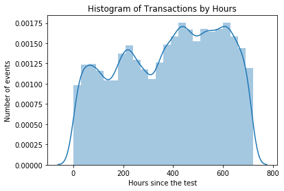

```python
#Create histograms for completed offer and transactions

#Create edges
bin_edges = np.arange(0, 700+30, 30)

#Plot histogram for completed offer
plt.figure(1)
sb.distplot(df_final.query('event == "offer completed"').time,
            bins= bin_edges);
plt.xlabel('Hours since the test')
plt.ylabel('Number of events')
plt.title('Histogram of Completed Offers by Hours')

#Plot histogram for transactions
plt.figure(2)
sb.distplot(df_final.query('event == "transaction"').time,
            bins= bin_edges);
plt.xlabel('Hours since the test')
plt.ylabel('Number of events')
plt.title('Histogram of Transactions by Hours')
```

```
Text(0.5,1,'Histogram of Duration of Completed Offers by Hours')
```

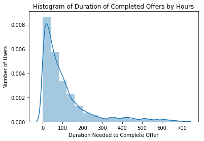

```python
#Create histogram for duration of receive to complete

#Create bins
bin_edges = np.arange(0, 700+40, 40)

#Plot histogram
sb.distplot(df_complete.time_before_complete,
            bins= bin_edges);
plt.xlabel('Duration Needed to Complete Offer')
plt.ylabel('Number of Users')
plt.title('Histogram of Duration of Completed Offers by Hours')
```

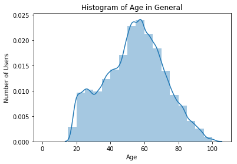

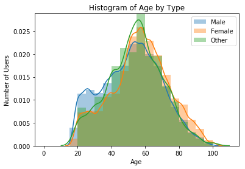

```python
#Create histograms for completed offer and transactions

#Create edges
bin_edges = np.arange(0, 100+5, 5)

#Plot histogram for Age in general
plt.figure(1)
sb.distplot(df_final.age,
            bins= bin_edges);
plt.xlabel('Age')
plt.ylabel('Number of Users')
plt.title('Histogram of Age in General');


#Plot histogram for Age Male and Female
plt.figure(2)
sb.distplot(df_final.query('M == 1').age,
            bins= bin_edges, label='Male');
sb.distplot(df_final.query('F == 1').age,
            bins= bin_edges, label='Female');
sb.distplot(df_final.query('O == 1').age,
            bins= bin_edges, label='Other');
plt.xlabel('Age')
plt.ylabel('Number of Users')
plt.title('Histogram of Age by Type');
plt.legend()
```

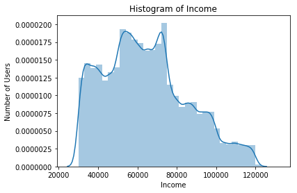

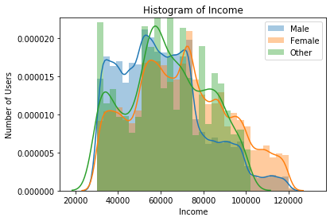

```python
#Create histograms for completed offer and transactions

#Create edges
bin_edges = np.arange(30000, 130000+3000, 3000)

#Plot histogram for users' income in general
plt.figure(1)
sb.distplot(df_final.income,
            bins= bin_edges);
plt.xlabel('Income')
plt.ylabel('Number of Users')
plt.title('Histogram of Income');

#Plot histogram for users based on gender
plt.figure(2)
sb.distplot(df_final.query('M == 1').income,
            bins= bin_edges, label='Male');
sb.distplot(df_final.query('F == 1').income,
            bins= bin_edges, label='Female');
sb.distplot(df_final.query('O == 1').income,
            bins= bin_edges, label='Other');
plt.xlabel('Income')
plt.ylabel('Number of Users')
plt.title('Histogram of Income');
plt.legend()
```

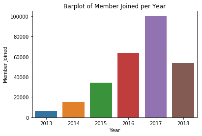

```python
#Plot barplot by member's joining time of year
sb.barplot([2013,2014,2015,2016,2017,2018],
           df_final.groupby('member_year')['customer_id'].count())
plt.xlabel('Year')
plt.ylabel('Member Joined')
plt.title('Barplot of Member Joined per Year');
```

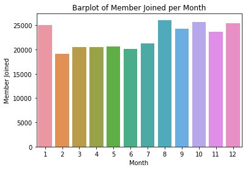

```python
#Plot barplot by member's joining time of month
sb.barplot([x for x in range(1,13)],
           df_final.groupby('member_month')['customer_id'].count())
plt.xlabel('Month')
plt.ylabel('Member Joined')
plt.title('Barplot of Member Joined per Month');
```

```python
incomplete = df_incomplete
complete = df_complete_receive

#Create dataset and add new columns
incomplete = pd.DataFrame(incomplete,
                          columns = df_final.columns)
incomplete['isComplete'] = 0

#Create dataset and add new columns
complete = pd.DataFrame(complete,
                        columns = df_final.columns)
complete['isComplete'] = 1
```

```python
#Check dataset
print(incomplete.shape[0])
incomplete.head()
```

```
32858
```

|  | event | customer_id | time | offer_id | amount | age | became_member_on | income | difficulty | duration | ... | web | bogo | discount | informational | F | M | O | member_year | member_month | isComplete |
| --- | --- | --- | --- | --- | --- | --- | --- | --- | --- | --- | --- | --- | --- | --- | --- | --- | --- | --- | --- | --- | --- |
| 0 | offer received | e2127556f4f64592b11af22de27a7932 | 0 | 2906b810c7d4411798c6938adc9daaa5 | NaN | 68 | 2018-04-26 | 70000.0 | 10.0 | 7.0 | ... | 1.0 | 0 | 1 | 0 | 0 | 1 | 0 | 2018 | 4 | 0 |
| 1 | offer received | 2eeac8d8feae4a8cad5a6af0499a211d | 0 | 3f207df678b143eea3cee63160fa8bed | NaN | 58 | 2017-11-11 | 51000.0 | 0.0 | 4.0 | ... | 1.0 | 0 | 0 | 1 | 0 | 1 | 0 | 2017 | 11 | 0 |
| 2 | offer received | aa4862eba776480b8bb9c68455b8c2e1 | 0 | 0b1e1539f2cc45b7b9fa7c272da2e1d7 | NaN | 61 | 2017-09-11 | 57000.0 | 20.0 | 10.0 | ... | 1.0 | 0 | 1 | 0 | 1 | 0 | 0 | 2017 | 9 | 0 |
| 3 | offer received | 31dda685af34476cad5bc968bdb01c53 | 0 | 0b1e1539f2cc45b7b9fa7c272da2e1d7 | NaN | 62 | 2016-02-11 | 71000.0 | 20.0 | 10.0 | ... | 1.0 | 0 | 1 | 0 | 1 | 0 | 0 | 2016 | 2 | 0 |
| 4 | offer received | c27e0d6ab72c455a8bb66d980963de60 | 0 | 3f207df678b143eea3cee63160fa8bed | NaN | 78 | 2017-06-16 | 71000.0 | 0.0 | 4.0 | ... | 1.0 | 0 | 0 | 1 | 1 | 0 | 0 | 2017 | 6 | 0 |

5 rows × 24 columns

```python
#Check dataset
print(complete.shape[0])
complete.head()
```

```
32444
```

|  | event | customer_id | time | offer_id | amount | age | became_member_on | income | difficulty | duration | ... | web | bogo | discount | informational | F | M | O | member_year | member_month | isComplete |
| --- | --- | --- | --- | --- | --- | --- | --- | --- | --- | --- | --- | --- | --- | --- | --- | --- | --- | --- | --- | --- | --- |
| 0 | offer received | 9fa9ae8f57894cc9a3b8a9bbe0fc1b2f | 0 | 2906b810c7d4411798c6938adc9daaa5 | NaN | 42 | 2016-01-17 | 96000.0 | 10.0 | 7.0 | ... | 1.0 | 0 | 1 | 0 | 0 | 1 | 0 | 2016 | 1 | 1 |
| 1 | offer received | fe97aa22dd3e48c8b143116a8403dd52 | 0 | fafdcd668e3743c1bb461111dcafc2a4 | NaN | 39 | 2017-12-17 | 67000.0 | 10.0 | 10.0 | ... | 1.0 | 0 | 1 | 0 | 1 | 0 | 0 | 2017 | 12 | 1 |
| 2 | offer received | 629fc02d56414d91bca360decdfa9288 | 0 | 9b98b8c7a33c4b65b9aebfe6a799e6d9 | NaN | 52 | 2018-06-05 | 72000.0 | 5.0 | 7.0 | ... | 1.0 | 1 | 0 | 0 | 0 | 1 | 0 | 2018 | 6 | 1 |
| 3 | offer received | 676506bad68e4161b9bbaffeb039626b | 0 | ae264e3637204a6fb9bb56bc8210ddfd | NaN | 37 | 2017-05-15 | 92000.0 | 10.0 | 7.0 | ... | 0.0 | 1 | 0 | 0 | 0 | 1 | 0 | 2017 | 5 | 1 |
| 4 | offer received | 8f7dd3b2afe14c078eb4f6e6fe4ba97d | 0 | 4d5c57ea9a6940dd891ad53e9dbe8da0 | NaN | 48 | 2015-09-03 | 62000.0 | 10.0 | 5.0 | ... | 1.0 | 1 | 0 | 0 | 0 | 1 | 0 | 2015 | 9 | 1 |

5 rows × 24 columns

```python
data = complete.append(incomplete)

data.head()
```

|  | event | customer_id | time | offer_id | amount | age | became_member_on | income | difficulty | duration | ... | web | bogo | discount | informational | F | M | O | member_year | member_month | isComplete |
| --- | --- | --- | --- | --- | --- | --- | --- | --- | --- | --- | --- | --- | --- | --- | --- | --- | --- | --- | --- | --- | --- |
| 0 | offer received | 9fa9ae8f57894cc9a3b8a9bbe0fc1b2f | 0 | 2906b810c7d4411798c6938adc9daaa5 | NaN | 42 | 2016-01-17 | 96000.0 | 10.0 | 7.0 | ... | 1.0 | 0 | 1 | 0 | 0 | 1 | 0 | 2016 | 1 | 1 |
| 1 | offer received | fe97aa22dd3e48c8b143116a8403dd52 | 0 | fafdcd668e3743c1bb461111dcafc2a4 | NaN | 39 | 2017-12-17 | 67000.0 | 10.0 | 10.0 | ... | 1.0 | 0 | 1 | 0 | 1 | 0 | 0 | 2017 | 12 | 1 |
| 2 | offer received | 629fc02d56414d91bca360decdfa9288 | 0 | 9b98b8c7a33c4b65b9aebfe6a799e6d9 | NaN | 52 | 2018-06-05 | 72000.0 | 5.0 | 7.0 | ... | 1.0 | 1 | 0 | 0 | 0 | 1 | 0 | 2018 | 6 | 1 |
| 3 | offer received | 676506bad68e4161b9bbaffeb039626b | 0 | ae264e3637204a6fb9bb56bc8210ddfd | NaN | 37 | 2017-05-15 | 92000.0 | 10.0 | 7.0 | ... | 0.0 | 1 | 0 | 0 | 0 | 1 | 0 | 2017 | 5 | 1 |
| 4 | offer received | 8f7dd3b2afe14c078eb4f6e6fe4ba97d | 0 | 4d5c57ea9a6940dd891ad53e9dbe8da0 | NaN | 48 | 2015-09-03 | 62000.0 | 10.0 | 5.0 | ... | 1.0 | 1 | 0 | 0 | 0 | 1 | 0 | 2015 | 9 | 1 |

5 rows × 24 columns

```python
data.groupby('isComplete')['income'].count()
```

```
isComplete
0    32858
1    32444
Name: income, dtype: int64
```

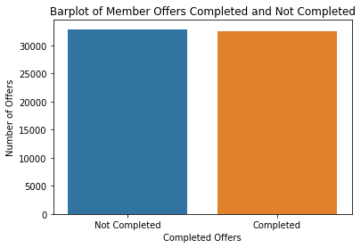

```python
#Plot barplot by completion of offers
sb.barplot(['Not Completed','Completed'],
           data.groupby('isComplete')['income'].count())
plt.xlabel('Completed Offers')
plt.ylabel('Number of Offers')
plt.title('Barplot of Member Offers Completed and Not Completed');
```

## Machine Learning

Offer received -> viewed -> transactions -> completed

```python
#Drop unneccesary columns for ML job
data.drop(columns=['amount','became_member_on','customer_id','event','offer_id'], inplace=True)
```

```python
#Declare X and y
X = data.iloc[:,:-1].values
y = data.iloc[:,-1].values
```

```python
#Splitting data to train and test set
from sklearn.model_selection import train_test_split
X_train,X_test,y_train,y_test = train_test_split(X, y,
                                                 train_size=0.8)
```

```python
#Import libraries
from sklearn.metrics import confusion_matrix as cm
from sklearn.metrics import classification_report as cr
from scipy import stats

#Define function for model testing
def test_model(classifier):
    # This function declare model, fit them to the data, predict, then print the classification report
    cls = classifier()
    cls.fit(X_train, y_train)
    y_pred = cls.predict(X_test)
    print(cr(y_test, y_pred))
```

```python
#Start with simplest algorithm for classification
from sklearn.linear_model import LogisticRegression
test_model(LogisticRegression)
```

```
             precision    recall  f1-score   support

          0       0.80      0.67      0.73      6555
          1       0.71      0.83      0.77      6506

avg / total       0.76      0.75      0.75     13061
```

```python
from sklearn.naive_bayes import MultinomialNB
test_model(MultinomialNB)
```

```
             precision    recall  f1-score   support

          0       0.59      0.62      0.61      6555
          1       0.60      0.57      0.59      6506

avg / total       0.60      0.60      0.60     13061
```

```python
from sklearn.naive_bayes import GaussianNB
test_model(GaussianNB)
```

```
             precision    recall  f1-score   support

          0       0.90      0.48      0.63      6555
          1       0.65      0.95      0.77      6506

avg / total       0.77      0.71      0.70     13061
```

```python
from sklearn.ensemble import RandomForestClassifier
test_model(RandomForestClassifier)
```

```
             precision    recall  f1-score   support

          0       0.78      0.78      0.78      6555
          1       0.78      0.77      0.78      6506

avg / total       0.78      0.78      0.78     13061
```

```python
from sklearn.ensemble import GradientBoostingClassifier
test_model(GradientBoostingClassifier)
```

```
             precision    recall  f1-score   support

          0       0.82      0.73      0.78      6555
          1       0.76      0.84      0.80      6506

avg / total       0.79      0.79      0.79     13061
```

```python
#More advanced algorithms
from xgboost import XGBClassifier
test_model(XGBClassifier)
```

```
             precision    recall  f1-score   support

          0       0.82      0.77      0.79      6555
          1       0.78      0.83      0.80      6506

avg / total       0.80      0.80      0.80     13061
```

```python
#Params distributions for CV
param_distributions = {
    'n_estimators': stats.randint(low=10, high=1000),
    'max_depth': stats.randint(low=2, high=6),
    'min_samples_split': stats.randint(low=2, high=5)
}
```

```python
#Searching for best hyperparameter
from sklearn.model_selection import RandomizedSearchCV

cls = RandomForestClassifier()
classification_cv = RandomizedSearchCV(
    cls, param_distributions=param_distributions,
    n_iter=50, verbose=1)
classification_cv.fit(X_train, y_train)

#Print best hyperparameter
print('Best params: \n', classification_cv.best_params_)

y_hat_train = classification_cv.predict(X_train)
y_hat_test = classification_cv.predict(X_test)

#Print classification report
print(cr(y_test, y_hat_test))
print(cr(y_train, y_hat_train))
```

[output not shown]

```
Fitting 3 folds for each of 50 candidates, totalling 150 fits
```

```
[Parallel(n_jobs=1)]: Done 150 out of 150 | elapsed: 21.5min finished
```

```
Best params:
 {'max_depth': 5, 'min_samples_split': 3, 'n_estimators': 102}
```

```
<Container object of 18 artists>
```

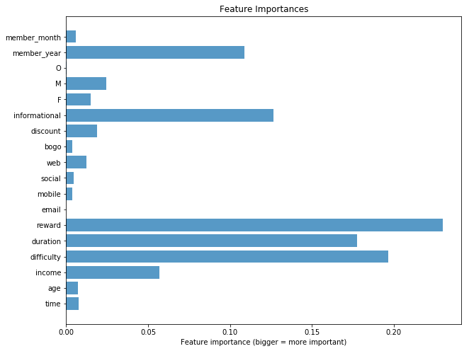

```python
#Plot feature importances from previous search
fig, ax = plt.subplots(1, 1, figsize=(10, 8))
ax = plt.axes()
ax.set_yticks(range(
    len(classification_cv.best_estimator_.feature_importances_)))
ax.set_yticklabels(data.columns[:-1])
ax.set_xlabel("Feature importance (bigger = more important)")
ax.set_title('Feature Importances')
ax.barh(range(
    len(classification_cv.best_estimator_.feature_importances_)),
        classification_cv.best_estimator_.feature_importances_,
        alpha=0.75)
```